# SI 618: Data Manipulation and Analysis

## 07 Beyond regex: Natural Language Processing

### Dr. Chris Teplovs, School of Information, University of Michigan

This work is licensed under a [Creative Commons Attribution-NonCommercial-ShareAlike 4.0 International License](http://creativecommons.org/licenses/by-nc-sa/4.0/).

### Please ensure you have this version:

Version 2023.10.10.1.CT

# Updates

- project team formation

```python
import pandas as pd
import numpy as np
import re
import seaborn as sns
import matplotlib.pyplot as plt
```

# spaCy

- Fast, and extensible NLP package for Python
- https://spacy.io/
- NOTE: You will need to install this, and then (one time only as well) download the English corpus.

```python
import spacy
```

```python
# NOTE: You should have already installed the following language model
#       when you created your .venv virtual environment.  It is included
#       in case you need to install it again, in which case you can uncomment
#       the following line and run it.
# !python -m spacy download en_core_web_sm
```

```python
# loading up the language model: English
# note that Windows users might need to figure out where
# the previous cell installed the library and change the following line accordingly
nlp = spacy.load('en_core_web_sm')
```

```python
# from Make It Stick: The Science of Successful Learning
sentences = """Michael Young is a high-achieving fourth-year medical
student at Georgia Regents University who pulled himself up from rock
bottom by changing the way he studies. Young entered medical school
without the usual foundation of premed coursework. His classmates all had
backgrounds in biochemistry, pharmacology, and the like. Medical
school is plenty tough under any circumstances, but in Young's
case even more so for lack of a footing."""
```

```python
print(sentences)
```

```
Michael Young is a high-achieving fourth-year medical
student at Georgia Regents University who pulled himself up from rock
bottom by changing the way he studies. Young entered medical school
without the usual foundation of premed coursework. His classmates all had
backgrounds in biochemistry, pharmacology, and the like. Medical
school is plenty tough under any circumstances, but in Young's
case even more so for lack of a footing.
```

```python
sentences
```

```
"Michael Young is a high-achieving fourth-year medical\nstudent at Georgia Regents University who pulled himself up from rock\nbottom by changing the way he studies. Young entered medical school\nwithout the usual foundation of premed coursework. His classmates all had\nbackgrounds in biochemistry, …
```

### Goal: calculate the frequency of each word

- See which words are more frequent
- Generate a meaningful summary for the above paragraph?

#### Normalizing the text by lowering the case

```python
type(sentences)
```

```
str
```

```python
sentences_lower = sentences.lower()
sentences_lower
```

```
"michael young is a high-achieving fourth-year medical\nstudent at georgia regents university who pulled himself up from rock\nbottom by changing the way he studies. young entered medical school\nwithout the usual foundation of premed coursework. his classmates all had\nbackgrounds in biochemistry, …
```

## 0-2. remove punctuation and special characters

#### Alternatively, we can use regular expression to remove punctuations

- So we don't have to list up all possible special characters that we want to remove
- https://docs.python.org/3.4/library/re.html
- https://en.wikipedia.org/wiki/Regular_expression

```python
sentences_lower_no_punctuation = re.sub(r'[^\w\s]+', ' ', sentences_lower)
sentences_lower_no_punctuation
```

```
'michael young is a high achieving fourth year medical\nstudent at georgia regents university who pulled himself up from rock\nbottom by changing the way he studies  young entered medical school\nwithout the usual foundation of premed coursework  his classmates all had\nbackgrounds in biochemistry  …
```

### And one more way...

Regular expressions:

^ means "beginning of string" UNLESS it's in [ ], in which case it means "not"

r'^The' # means The at the beginning of a string r'^[The]' # means any one of T or h or e at the beginning of a string t'^[^The]' # means any character other than T,h,or e at the beginning

```python
# remove punctuation and special characters from the sentences_lower string
sentences_lower_no_punctuation = re.sub(r'[^\w\s]+', ' ', sentences_lower)
sentences_lower_no_punctuation
```

```
'michael young is a high achieving fourth year medical\nstudent at georgia regents university who pulled himself up from rock\nbottom by changing the way he studies  young entered medical school\nwithout the usual foundation of premed coursework  his classmates all had\nbackgrounds in biochemistry  …
```

And still one more way:

```python
import string
string.punctuation
```

```
'!"#$%&\'()*+,-./:;<=>?@[\\]^_`{|}~'
```

```python
# remove punctuation and special characters from the sentences_lower string using maketrans:
sentences_lower_no_punctuation = sentences_lower.translate(
    str.maketrans('', '', string.punctuation))
sentences_lower_no_punctuation
```

```
'michael young is a highachieving fourthyear medical\nstudent at georgia regents university who pulled himself up from rock\nbottom by changing the way he studies young entered medical school\nwithout the usual foundation of premed coursework his classmates all had\nbackgrounds in biochemistry pharm…
```

Remember our task at hand: determining the frequency of each word in a document.

- Split the paragraph into a list of words

```python
words = sentences_lower_no_punctuation.split()
```

```python
words[:10]
```

```
['michael',
 'young',
 'is',
 'a',
 'highachieving',
 'fourthyear',
 'medical',
 'student',
 'at',
 'georgia']
```

- Count the words from the list
- Words that can occur in any kind of paragraphs...?

```python
d = {}
for word in words:
    if word in d:
        d[word] = d[word] + 1
    else:
        d[word] = 1
d
```

```
{'michael': 1,
 'young': 2,
 'is': 2,
 'a': 2,
 'highachieving': 1,
 'fourthyear': 1,
 'medical': 3,
 'student': 1,
 'at': 1,
 'georgia': 1,
 'regents': 1,
 'university': 1,
 'who': 1,
 'pulled': 1,
 'himself': 1,
 'up': 1,
 'from': 1,
 'rock': 1,
 'bottom': 1,
 'by': 1,
 'changing': 1,
 'the': 3,
 'way': 1,
 'he': 1,
 'studies': 1,
 'entered': 1,
 'school': 2,
 'without': 1,
 'usual': 1,
 'foundation': 1,
 'of': 2,
 'premed': 1,
 'coursework': 1,
 'his': 1,
 'classmates': 1,
 'all': 1,
 'had': 1,
 'backgrounds': 1,
 'in': 2,
 'biochemistry': 1,
 'pharmacology': 1,
 'and': 1,
 'like': 1,
 'plenty': 1,
 'tough': 1,
 'under': 1,
 'any': 1,
 'circumstances': 1,
 'but': 1,
 'youngs': 1,
 'case': 1,
 'even': 1,
 'more': 1,
 'so': 1,
 'for': 1,
 'lack': 1,
 'footing': 1}
```

```python
from collections import defaultdict
d = defaultdict(int)
for word in words:
    d[word] += 1
```

```python
from collections import Counter
```

```python
Counter(words).most_common(20)
```

```
[('medical', 3),
 ('the', 3),
 ('young', 2),
 ('is', 2),
 ('a', 2),
 ('school', 2),
 ('of', 2),
 ('in', 2),
 ('michael', 1),
 ('highachieving', 1),
 ('fourthyear', 1),
 ('student', 1),
 ('at', 1),
 ('georgia', 1),
 ('regents', 1),
 ('university', 1),
 ('who', 1),
 ('pulled', 1),
 ('himself', 1),
 ('up', 1)]
```

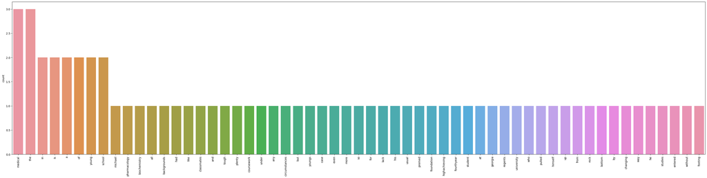

```python
plt.figure(figsize=(45,10))
sns.countplot(x=words, order=pd.Series(words).value_counts().index)
# sns.countplot(words_nostop, order=[counted[0] for counted in Counter(words_nostop).most_common()])
plt.xticks(rotation=90)
plt.show()
```

## 0-3. Remove stop words

- Stop words usually refers to the most common words in a language
  - No single universal stopwords
  - Often stopwords are removed to improve the performance of NLP models
  - https://en.wikipedia.org/wiki/Stop_words
  - https://en.wikipedia.org/wiki/Most_common_words_in_English

#### Import the list of stop words from `spaCy`

```python
from spacy.lang.en.stop_words import STOP_WORDS
```

```python
STOP_WORDS
```

```
{"'d",
 "'ll",
 "'m",
 "'re",
 "'s",
 "'ve",
 'a',
 'about',
 'above',
 'across',
 'after',
 'afterwards',
 'again',
 'against',
 'all',
 'almost',
 'alone',
 'along',
 'already',
 'also',
 'although',
 'always',
 'am',
 'among',
 'amongst',
 'amount',
 'an',
 'and',
 'another',
 'any',
 'anyhow',
 'anyone',
 'anything',
 'anyway',
 'anywhere',
 'are',
 'around',
 'as',
 'at',
 'back',
```

[output cut: 271 more lines]

```
 'yours',
 'yourself',
 'yourselves',
 '‘d',
 '‘ll',
 '‘m',
 '‘re',
 '‘s',
 '‘ve',
 '’d',
 '’ll',
 '’m',
 '’re',
 '’s',
 '’ve'}
```

#### Goal: We are going to count the frequency of each word from the paragraph, to see which words can be used to represent the paragraph's content.

- Note that our paragraph is stored as a single string object...

#### When we removed stopwords:

```python
words_no_stopwords = list()
for word in words:
    if word not in STOP_WORDS:
        words_no_stopwords.append(word)
```

### Q1: Re-implement the code in the previous cell using a list comprehension

```python
words_no_stopwords = [ word for word in words if word not in STOP_WORDS ]
```

### Q2: Use a `Counter` to find the frequencies of each word in the `words_nostop` list.

```python
# insert your code here
Counter(words_no_stopwords).most_common(20)
```

```
[('medical', 3),
 ('young', 2),
 ('school', 2),
 ('michael', 1),
 ('highachieving', 1),
 ('fourthyear', 1),
 ('student', 1),
 ('georgia', 1),
 ('regents', 1),
 ('university', 1),
 ('pulled', 1),
 ('rock', 1),
 ('changing', 1),
 ('way', 1),
 ('studies', 1),
 ('entered', 1),
 ('usual', 1),
 ('foundation', 1),
 ('premed', 1),
 ('coursework', 1)]
```

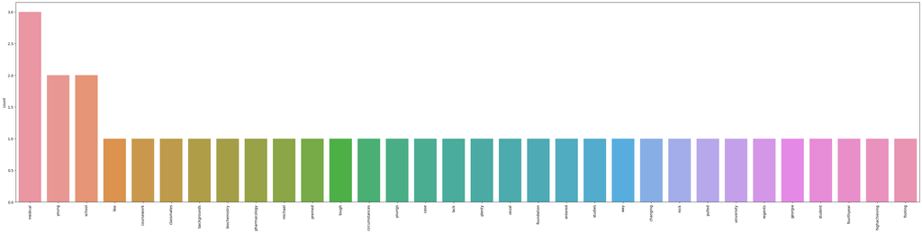

```python
# insert your code here
plt.figure(figsize=(45,10))
sns.countplot(x=words_no_stopwords, \
    order=pd.Series(words_no_stopwords).value_counts().index)
# sns.countplot(words_nostop, order=[counted[0] for counted in Counter(words_nostop).most_common()])
plt.xticks(rotation=90)
plt.show()
```

# 1. Extracting linguistic features from spaCy

## 1-1. Tokenize

- Token: a semantic unit for analysis
  - (Loosely) equal term for word
    - `sent_low_pnct.split()`
  - Tricky cases
    - aren't $\rightarrow$

[figure not shown]

      ?

[figure not shown]

      ?
    - O'Neil $\rightarrow$

[figure not shown]

      ?

[figure not shown]

      ?
    - https://nlp.stanford.edu/IR-book/html/htmledition/tokenization-1.html
- In `spaCy`:
  - Many token types, like word, punctuation symbol, whitespace, etc.

### Let's dissect the sentence!

- initializing the `spaCy` object

```python
# examples partially taken from (now defunct) https://nlpforhackers.io/complete-guide-to-spacy/
import spacy
nlp = spacy.load('en_core_web_sm')
```

```python
type(nlp)
```

```
spacy.lang.en.English
```

- Our sentence: "Hello World!"
  - Pass the sentence string to the `spaCy` object `nlp`

```python
doc = nlp("Hello World!")
```

- The sentence is considered as a short document.

```python
print(type(doc), doc)
```

```
<class 'spacy.tokens.doc.Doc'> Hello World!
```

```python
doc[0]
```

```
Hello
```

```python
doc.text[0]
```

```
'H'
```

- As importing the sentence string above, `spaCy` split the sentence into tokens (tokenization!)

```python
for i,token in enumerate(doc):
    print(i, token)
```

```
0 Hello
1 World
2 !
```

- With index information (location from the sentence) of each token

| 0 | 1 | 2 | 3 | 4 | 5 | 6 | 7 | 8 | 9 | 10 | 11 |
| --- | --- | --- | --- | --- | --- | --- | --- | --- | --- | --- | --- |
| H | e | l | l | o | _ | W | o | r | l | d | ! |

```python
for i, token in enumerate(doc):
    print(i, token.text, token.idx)
```

```
0 Hello 0
1 World 6
2 ! 11
```

- And many more!
  - https://spacy.io/api/token#attributes

```python
sentences
```

```
"Michael Young is a high-achieving fourth-year medical\nstudent at Georgia Regents University who pulled himself up from rock\nbottom by changing the way he studies. Young entered medical school\nwithout the usual foundation of premed coursework. His classmates all had\nbackgrounds in biochemistry, …
```

```python
doc = nlp(sentences)

print("text\tidx\tlemma\tlower\tpunct\tspace\tshape\tPOS")
for token in doc:
    if token.is_space:
        print("SPACE")
    else:
        print("{0}\t{1}\t{2}\t{3}\t{4}\t{5}\t{6}\t{7}".format(
            token.text,
            token.idx,
            token.lemma_,
            token.lower_,
            token.is_punct,
            token.is_space,
            token.shape_,
            token.pos_
    ))
```

```
text	idx	lemma	lower	punct	space	shape	POS
Michael	0	Michael	michael	False	False	Xxxxx	PROPN
Young	8	Young	young	False	False	Xxxxx	PROPN
is	14	be	is	False	False	xx	AUX
a	17	a	a	False	False	x	DET
high	19	high	high	False	False	xxxx	ADV
-	23	-	-	True	False	-	PUNCT
achieving	24	achieve	achieving	False	False	xxxx	VERB
fourth	34	fourth	fourth	False	False	xxxx	ADJ
-	40	-	-	True	False	-	PUNCT
year	41	year	year	False	False	xxxx	NOUN
medical	46	medical	medical	False	False	xxxx	ADJ
SPACE
student	54	student	student	False	False	xxxx	NOUN
at	62	at	at	False	False	xx	ADP
Georgia	65	Georgia	georgia	False	False	Xxxxx	PROPN
Regents	73	Regents	regents	False	False	Xxxxx	PROPN
University	81	University	university	False	False	Xxxxx	PROPN
who	92	who	who	False	False	xxx	PRON
pulled	96	pull	pulled	False	False	xxxx	VERB
himself	103	himself	himself	False	False	xxxx	PRON
up	111	up	up	False	False	xx	ADP
from	114	from	from	False	False	xxxx	ADP
rock	119	rock	rock	False	False	xxxx	NOUN
SPACE
bottom	124	bottom	bottom	False	False	xxxx	NOUN
by	131	by	by	False	False	xx	ADP
changing	134	change	changing	False	False	xxxx	VERB
the	143	the	the	False	False	xxx	DET
way	147	way	way	False	False	xxx	NOUN
he	151	he	he	False	False	xx	PRON
studies	154	study	studies	False	False	xxxx	VERB
.	161	.	.	True	False	.	PUNCT
Young	163	Young	young	False	False	Xxxxx	PROPN
entered	169	enter	entered	False	False	xxxx	VERB
medical	177	medical	medical	False	False	xxxx	ADJ
school	185	school	school	False	False	xxxx	NOUN
SPACE
without	192	without	without	False	False	xxxx	ADP
the	200	the	the	False	False	xxx	DET
```

[output cut: 31 more lines]

```
but	379	but	but	False	False	xxx	CCONJ
in	383	in	in	False	False	xx	ADP
Young	386	Young	young	False	False	Xxxxx	PROPN
's	391	's	's	False	False	'x	PART
SPACE
case	394	case	case	False	False	xxxx	NOUN
even	399	even	even	False	False	xxxx	ADV
more	404	more	more	False	False	xxxx	ADV
so	409	so	so	False	False	xx	ADV
for	412	for	for	False	False	xxx	ADP
lack	416	lack	lack	False	False	xxxx	NOUN
of	421	of	of	False	False	xx	ADP
a	424	a	a	False	False	x	DET
footing	426	footing	footing	False	False	xxxx	NOUN
.	433	.	.	True	False	.	PUNCT
```

```python
doc = nlp(sentences)

print("text\tidx\tlemma\tlower\tpunct\tspace\tstop\tshape\tPOS")
for token in doc:
    if token.is_space:
        print("SPACE")
    else:
        print("{0}\t{1}\t{2}\t{3}\t{4}\t{5}\t{6}\t{7}\t{8}".format(
            token.text,
            token.idx,
            token.lemma_,
            token.lower_,
            token.is_punct,
            token.is_space,
            token.is_stop,
            token.shape_,
            token.pos_
    ))
```

```
text	idx	lemma	lower	punct	space	stop	shape	POS
Michael	0	Michael	michael	False	False	False	Xxxxx	PROPN
Young	8	Young	young	False	False	False	Xxxxx	PROPN
is	14	be	is	False	False	True	xx	AUX
a	17	a	a	False	False	True	x	DET
high	19	high	high	False	False	False	xxxx	ADV
-	23	-	-	True	False	False	-	PUNCT
achieving	24	achieve	achieving	False	False	False	xxxx	VERB
fourth	34	fourth	fourth	False	False	False	xxxx	ADJ
-	40	-	-	True	False	False	-	PUNCT
year	41	year	year	False	False	False	xxxx	NOUN
medical	46	medical	medical	False	False	False	xxxx	ADJ
SPACE
student	54	student	student	False	False	False	xxxx	NOUN
at	62	at	at	False	False	True	xx	ADP
Georgia	65	Georgia	georgia	False	False	False	Xxxxx	PROPN
Regents	73	Regents	regents	False	False	False	Xxxxx	PROPN
University	81	University	university	False	False	False	Xxxxx	PROPN
who	92	who	who	False	False	True	xxx	PRON
pulled	96	pull	pulled	False	False	False	xxxx	VERB
himself	103	himself	himself	False	False	True	xxxx	PRON
up	111	up	up	False	False	True	xx	ADP
from	114	from	from	False	False	True	xxxx	ADP
rock	119	rock	rock	False	False	False	xxxx	NOUN
SPACE
bottom	124	bottom	bottom	False	False	True	xxxx	NOUN
by	131	by	by	False	False	True	xx	ADP
changing	134	change	changing	False	False	False	xxxx	VERB
the	143	the	the	False	False	True	xxx	DET
way	147	way	way	False	False	False	xxx	NOUN
he	151	he	he	False	False	True	xx	PRON
studies	154	study	studies	False	False	False	xxxx	VERB
.	161	.	.	True	False	False	.	PUNCT
Young	163	Young	young	False	False	False	Xxxxx	PROPN
entered	169	enter	entered	False	False	False	xxxx	VERB
medical	177	medical	medical	False	False	False	xxxx	ADJ
school	185	school	school	False	False	False	xxxx	NOUN
SPACE
without	192	without	without	False	False	True	xxxx	ADP
the	200	the	the	False	False	True	xxx	DET
```

[output cut: 31 more lines]

```
but	379	but	but	False	False	True	xxx	CCONJ
in	383	in	in	False	False	True	xx	ADP
Young	386	Young	young	False	False	False	Xxxxx	PROPN
's	391	's	's	False	False	True	'x	PART
SPACE
case	394	case	case	False	False	False	xxxx	NOUN
even	399	even	even	False	False	True	xxxx	ADV
more	404	more	more	False	False	True	xxxx	ADV
so	409	so	so	False	False	True	xx	ADV
for	412	for	for	False	False	True	xxx	ADP
lack	416	lack	lack	False	False	False	xxxx	NOUN
of	421	of	of	False	False	True	xx	ADP
a	424	a	a	False	False	True	x	DET
footing	426	footing	footing	False	False	False	xxxx	NOUN
.	433	.	.	True	False	False	.	PUNCT
```

#### Qx:

Create a bar chart, similar to the previous one, that uses the output from the spacy tokenizer. You should exclude punctuation, spaces and stopwords.

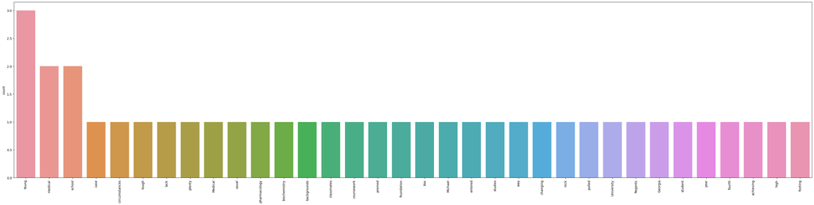

```python
# SOLUTION: delete

# Create a bar chart, similar to the previous one, that uses the output from the spacy tokenizer.  You should exclude punctuation, spaces and stopwords.
doc = nlp(sentences)
words = [token.text for token in doc if not token.is_punct and not token.is_space and not token.is_stop]
plt.figure(figsize=(45,10))
sns.countplot(x=words, order=pd.Series(words).value_counts().index)
plt.xticks(rotation=90)
plt.show()
```

## 1-2. Sentence detection

- For the document with multiple sentences, we would need to separate each sentence.
- In `spaCy`, the job is more convenient (and would cause less mistakes) than using regular expression

```python
sentences
```

```
"Michael Young is a high-achieving fourth-year medical\nstudent at Georgia Regents University who pulled himself up from rock\nbottom by changing the way he studies. Young entered medical school\nwithout the usual foundation of premed coursework. His classmates all had\nbackgrounds in biochemistry, …
```

```python
# same document, but initiate as the spaCy object...
doc = nlp(sentences)
doc
```

```
Michael Young is a high-achieving fourth-year medical
student at Georgia Regents University who pulled himself up from rock
bottom by changing the way he studies. Young entered medical school
without the usual foundation of premed coursework. His classmates all had
backgrounds in biochemistry, pharmacology, and the like. Medical
school is plenty tough under any circumstances, but in Young's
case even more so for lack of a footing.
```

- Sentences are stored as a generator object
  - Instead of storing sentences as a list, each sentence is stored as a item in the generator object
  - Iteratable (i.e., can be used in a for loop)
  - More efficient memory use
  - https://wiki.python.org/moin/Generators

```python
doc.sents
```

```
<generator at 0x14aada700>
```

- Printing sentences with the index number

```python
for i, sent in enumerate(doc.sents):
    print(i, sent)
```

```
0 Michael Young is a high-achieving fourth-year medical
student at Georgia Regents University who pulled himself up from rock
bottom by changing the way he studies.
1 Young entered medical school
without the usual foundation of premed coursework.
2 His classmates all had
backgrounds in biochemistry, pharmacology, and the like.
3 Medical
school is plenty tough under any circumstances, but in Young's
case even more so for lack of a footing.
```

## 1-3. Part-of-speech (POS) tagging

- I want to find words with particular part-of-speech!
- Different part-of-speech words carry different information
  - e.g., noun (subject), verb (action term), adjective (quality of the object)
- https://spacy.io/usage/linguistic-features#pos-tagging
- Yelp review!

```python
# from https://www.yelp.com/biz/ajishin-novi?hrid=juA4Zn2TX7845vNFn4syBQ&utm_campaign=www_review_share_popup&utm_medium=copy_link&utm_source=(direct)
doc = nlp("""One of the best Japanese restaurants in Novi. Simple food, great taste, amazingly price. I visit this place a least twice month.""")
```

- multiple sentences exist in a document

```python
for i, sent in enumerate(doc.sents):
    print(i, sent)
```

```
0 One of the best Japanese restaurants in Novi.
1 Simple food, great taste, amazingly price.
2 I visit this place a least twice month.
```

- Question: which words are adjectives (ADJ)?

```python
for i, sent in enumerate(doc.sents):
    for token in sent:
        if token.pos_ == 'ADJ':
            print(token.text, "\t", token.pos_)
```

```
best 	 ADJ
Japanese 	 ADJ
Simple 	 ADJ
great 	 ADJ
least 	 ADJ
twice 	 ADJ
```

```python
for i, sent in enumerate(doc.sents):
    for token in sent:
        if token.pos_ == 'NOUN':
            print(token.text, "\t", token.pos_)
```

```
restaurants 	 NOUN
food 	 NOUN
taste 	 NOUN
price 	 NOUN
place 	 NOUN
month 	 NOUN
```

## Named Entity Recognition

```python
doc = nlp(sentences)
print([(X.text, X.label_) for X in doc.ents])
```

```
[('Michael Young', 'PERSON'), ('fourth-year', 'DATE'), ('Georgia Regents University', 'ORG'), ('Young', 'PERSON')]
```

```python
url = 'https://fivethirtyeight.com/features/remembering-alex-trebek-the-man-with-all-the-answers/'
```

```python
from bs4 import BeautifulSoup
import requests
import re
def url_to_string(url):
    res = requests.get(url)
    html = res.text
    soup = BeautifulSoup(html)
    for script in soup(["script", "style", 'aside']):
        script.extract()
    return " ".join(re.split(r'[\n\t]+', soup.get_text()))
ny_bb = url_to_string(url)
article = nlp(ny_bb)
len(article.ents)
```

```
106
```

```python
article
```

```
 Remembering Alex Trebek, The Man With All The Answers | FiveThirtyEight Skip to main content FiveThirtyEight Search Search ABC News Menu Remembering Alex Trebek, The Man With All The Answers Share on Facebook Share on Twitter Politics Sports Science Podcasts Video Interactives ABC News   This is an…
```

```python
labels = [(x.label_,x.text) for x in article.ents]
Counter(labels)
```

```
Counter({('PERSON', 'Trebek'): 14,
         ('WORK_OF_ART', 'Jeopardy'): 7,
         ('PERSON', 'Alex Trebek'): 5,
         ('WORK_OF_ART', 'The Man With All The Answers'): 2,
         ('DATE', '1984'): 2,
         ('PERSON', 'Alex'): 2,
         ('DATE', '2023'): 2,
         ('ORG', 'ABC News Internet Ventures'): 2,
         ('ORG', 'ABC News'): 1,
         ('WORK_OF_ART',
          'The Man With All The Answers Share on Facebook Share on Twitter Politics Sports Science Podcasts Video Interactives ABC News'): 1,
         ('CARDINAL', '538'): 1,
         ('DATE', 'Nov. 9, 2020'): 1,
         ('TIME', '4:09 PM'): 1,
         ('PERSON', 'Oliver Roeder Filed'): 1,
         ('ORG', 'Jeopardy'): 1,
         ('PERSON', 'FIVETHIRTYEIGHT'): 1,
         ('DATE', 'decades'): 1,
         ('DATE', 'Sunday'): 1,
         ('DATE', 'age 80'): 1,
         ('DATE', 'April Fool’s Day'): 1,
         ('DATE', '1997'): 1,
         ('PERSON', 'Pat Sajak'): 1,
         ('WORK_OF_ART', 'Wheel of Fortune'): 1,
         ('CARDINAL', 'more than 8,000'): 1,
         ('TIME', 'half-hour'): 1,
         ('DATE', 'the past few years'): 1,
         ('CARDINAL', 'two'): 1,
         ('DATE', 'this past Friday'): 1,
         ('PERSON', 'Rihanna'): 1,
         ('PERSON', 'Madonna'): 1,
         ('PERSON', 'Katy Perry'): 1,
         ('GPE', 'Vaduz'): 1,
         ('NORP', 'Russian'): 1,
         ('NORP', 'German'): 1,
         ('PERSON', 'Gene Wilder'): 1,
         ('LOC', 'the Cook Strait'): 1,
         ('ORG', 'Congress'): 1,
         ('NORP', 'Trebek'): 1,
         ('DATE', 'the last few years'): 1,
```

[output cut: 24 more lines]

```
         ('PERSON', 'Ken Jennings'): 1,
         ('CARDINAL', '74'): 1,
         ('DATE', 'March 2019'): 1,
         ('CARDINAL', '4'): 1,
         ('DATE', 'three more years'): 1,
         ('PERSON', 'Oliver Roeder'): 1,
         ('WORK_OF_ART', 'Ph.D.'): 1,
         ('ORG', 'the University of Texas'): 1,
         ('GPE', 'Austin'): 1,
         ('PRODUCT', 'Comments Filed'): 1,
         ('PERSON', 'Games'): 1,
         ('CARDINAL', '48'): 1,
         ('WORK_OF_ART', 'FiveThirtyEight Store Newsletter'): 1,
         ('ORG', 'WordPress'): 1,
         ('PERSON', 'Cookie Policy'): 1})
```

```python
labels = [x.label_ for x in article.ents]
Counter(labels)
```

```
Counter({'PERSON': 42,
         'DATE': 18,
         'WORK_OF_ART': 15,
         'ORG': 8,
         'CARDINAL': 8,
         'GPE': 4,
         'NORP': 4,
         'TIME': 2,
         'LOC': 1,
         'FAC': 1,
         'LANGUAGE': 1,
         'EVENT': 1,
         'PRODUCT': 1})
```

```python
labels
```

```
['PERSON',
 'WORK_OF_ART',
 'ORG',
 'PERSON',
 'WORK_OF_ART',
 'CARDINAL',
 'DATE',
 'TIME',
 'PERSON',
 'WORK_OF_ART',
 'PERSON',
 'ORG',
 'PERSON',
 'DATE',
 'WORK_OF_ART',
 'DATE',
 'PERSON',
 'DATE',
 'PERSON',
 'WORK_OF_ART',
 'DATE',
 'DATE',
 'DATE',
 'PERSON',
 'WORK_OF_ART',
 'CARDINAL',
 'TIME',
 'PERSON',
 'DATE',
 'CARDINAL',
 'PERSON',
 'WORK_OF_ART',
 'DATE',
 'PERSON',
 'PERSON',
 'PERSON',
 'GPE',
 'NORP',
 'NORP',
 'PERSON',
```

[output cut: 51 more lines]

```
 'PERSON',
 'PERSON',
 'WORK_OF_ART',
 'ORG',
 'GPE',
 'PRODUCT',
 'PERSON',
 'CARDINAL',
 'WORK_OF_ART',
 'ORG',
 'DATE',
 'ORG',
 'DATE',
 'ORG',
 'PERSON']
```

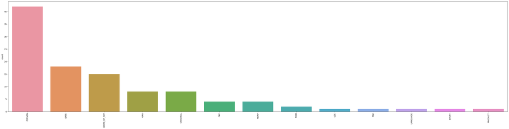

```python
plt.figure(figsize=(45,10))
sns.countplot(x=labels, order=pd.Series(labels).value_counts().index)
# sns.countplot(words_nostop, order=[counted[0] for counted in Counter(words_nostop).most_common()])
plt.xticks(rotation=90)
plt.show()
```

# 1. Word embedding

#### Word2Vec

- Developed by [Mikolov et al., 2013](https://papers.nips.cc/paper/5021-distributed-representations-of-words-and-phrases-and-their-compositionality.pdf)
- Represent the meaning of the words as a vector
  - Vector: numeric array
  - Output of a neural network model that predicts the next word
- Surprisingly, many different semantic informations can be represented from word vectors of `Word2Vec`
- (More explanation in here: https://www.tensorflow.org/tutorials/representation/word2vec)

You will also need to download a pretrained language model: https://github.com/eyaler/word2vec-slim/raw/master/GoogleNews-vectors-negative300-SLIM.bin.gz

```python
import gensim
```

Change the filepath in the next cell to correspond to the location of the pretrained model file you downloaded above.

```python
# w2v_mod = gensim.models.KeyedVectors.load_word2vec_format("~/Downloads/GoogleNews-vectors-negative300-SLIM.bin.gz", binary=True)
```

There are several pretrained models that you can access. See https://github.com/RaRe-Technologies/gensim-data/blob/master/list.json for a list of available models.

```python
import gensim.downloader as api
# Google News is about 1.6GB, which you can download on your own
w2v_mod = api.load('word2vec-google-news-300')
```

## 1-1. Calculating similarity between words

- Q: What's similarity between *school* and *student*?
- the word vector for *school* looks like this:

```python
w2v_mod['school']
```

```
array([ 9.13085938e-02,  2.81982422e-02,  3.68652344e-02,  2.18750000e-01,
        9.76562500e-02, -6.59179688e-02,  1.56250000e-01, -4.68750000e-02,
       -4.66918945e-03, -9.08203125e-02,  2.49023438e-01,  4.56542969e-02,
        6.64062500e-02, -9.86328125e-02, -1.05957031e-01,  1.06445312e-01,
       -2.00195312e-01,  1.40991211e-02,  1.36718750e-01, -8.78906250e-02,
        2.05078125e-01,  1.70898438e-01,  1.16577148e-02,  1.71875000e-01,
        4.85229492e-03, -3.49609375e-01,  2.27355957e-03,  1.84570312e-01,
        1.19628906e-01, -2.51464844e-02,  1.02050781e-01, -1.06933594e-01,
        4.00390625e-02,  7.50732422e-03, -1.63085938e-01, -1.49414062e-01,
        2.28515625e-01, -5.02929688e-02,  4.63867188e-02,  1.25000000e-01,
        1.30615234e-02,  1.27929688e-01,  1.10351562e-01, -5.05371094e-02,
        3.44238281e-02,  1.44531250e-01,  1.71875000e-01, -2.78320312e-02,
       -1.10839844e-01,  2.29492188e-01, -1.17187500e-01, -1.22070312e-01,
       -3.55529785e-03, -1.13769531e-01,  2.11914062e-01, -2.08984375e-01,
       -1.04492188e-01,  4.39453125e-02, -1.23291016e-02, -1.59179688e-01,
       -8.83789062e-02, -4.00390625e-02,  1.06445312e-01, -5.07812500e-02,
        7.76367188e-02,  1.46484375e-01, -1.72851562e-01,  2.07031250e-01,
        2.20947266e-02,  4.05273438e-02, -1.83593750e-01,  1.21093750e-01,
        8.69140625e-02,  3.68652344e-02, -1.11328125e-01,  3.55468750e-01,
        2.87109375e-01,  3.18908691e-03,  1.72851562e-01,  1.58203125e-01,
        4.98046875e-02, -1.66992188e-01, -1.50390625e-01,  2.08007812e-01,
        5.51757812e-02,  3.95507812e-02,  3.71093750e-02,  2.37304688e-01,
        1.66015625e-01, -2.83203125e-02, -1.81884766e-02, -1.89453125e-01,
       -1.36718750e-02, -1.53320312e-01, -1.78222656e-02,  9.42382812e-02,
        1.59179688e-01,  6.34765625e-02, -6.25000000e-02,  7.17773438e-02,
       -4.78515625e-02, -1.33666992e-02, -1.38671875e-01,  6.12792969e-02,
       -2.17773438e-01, -8.34960938e-02,  1.29394531e-02,  5.56640625e-02,
       -2.17285156e-02, -2.08007812e-01, -2.30468750e-01,  1.69921875e-01,
       -3.36914062e-02, -4.51660156e-02,  1.65039062e-01, -2.51770020e-04,
        6.68945312e-02, -4.98046875e-02, -1.41601562e-01, -1.62109375e-01,
       -1.12304688e-01, -1.51977539e-02,  2.47802734e-02, -2.17285156e-02,
       -5.95703125e-02, -4.51660156e-02, -8.25195312e-02, -1.35742188e-01,
        3.06701660e-03,  8.20312500e-02,  9.08203125e-02, -3.55468750e-01,
       -1.94335938e-01, -1.02050781e-01, -1.32812500e-01, -2.99072266e-02,
        2.72216797e-02, -1.04308128e-05, -2.78320312e-02,  7.03125000e-02,
       -3.55468750e-01, -3.55468750e-01,  1.29882812e-01,  4.57763672e-03,
       -2.61230469e-02,  2.14843750e-01, -9.66796875e-02, -9.52148438e-02,
       -2.22167969e-02,  4.74929810e-04,  4.04296875e-01, -1.77734375e-01,
       -9.03320312e-02,  1.49414062e-01, -2.06054688e-01, -1.28906250e-01,
        2.55859375e-01, -2.39257812e-01,  1.07421875e-01, -7.27539062e-02,
```

[output cut: 21 more lines]

```
       -2.73437500e-01, -1.16210938e-01, -1.64062500e-01, -6.59179688e-02,
        1.63574219e-02, -6.13403320e-03,  3.19824219e-02,  9.76562500e-02,
        1.38671875e-01,  1.42578125e-01, -8.74023438e-02, -2.67578125e-01,
        1.15722656e-01, -2.60009766e-02,  1.92871094e-02,  2.51953125e-01,
        4.58984375e-02,  1.39648438e-01, -2.47070312e-01, -9.22851562e-02,
        9.57031250e-02, -5.61523438e-02,  3.63769531e-02,  6.64062500e-02,
       -4.66308594e-02,  5.98144531e-02,  1.01562500e-01, -4.68750000e-02,
        9.08203125e-02,  2.08984375e-01, -7.81250000e-02, -2.51953125e-01,
        3.06640625e-01, -3.14453125e-01, -6.07910156e-02, -3.10546875e-01,
       -1.17187500e-01, -5.05371094e-02, -1.36718750e-01,  2.51953125e-01,
       -1.91406250e-01, -4.88281250e-04, -9.32617188e-02,  1.96289062e-01,
        1.51367188e-01,  2.98828125e-01, -1.07910156e-01, -2.39257812e-02,
       -1.47460938e-01, -6.68945312e-02,  1.04980469e-01, -5.73730469e-02,
       -1.05957031e-01, -1.25122070e-02,  9.08203125e-02,  1.20117188e-01],
      dtype=float32)
```

```python
len(w2v_mod['school'])
```

```
300
```

- and the word vector for *student* looks like this:

```python
w2v_mod['student']
```

```
array([ 0.03686523,  0.0201416 ,  0.22167969,  0.15527344,  0.17871094,
        0.03149414,  0.31445312, -0.03369141,  0.15429688, -0.375     ,
        0.05102539, -0.13183594, -0.11962891, -0.13867188, -0.02026367,
        0.01318359, -0.06738281, -0.06591797, -0.02502441, -0.140625  ,
        0.02160645,  0.17382812, -0.00177765, -0.09179688, -0.09765625,
       -0.4921875 , -0.13671875, -0.00570679,  0.16992188,  0.10107422,
        0.09423828, -0.10986328, -0.08496094,  0.05419922, -0.06542969,
       -0.0168457 ,  0.11230469,  0.13964844, -0.08300781,  0.22265625,
       -0.23828125,  0.11767578, -0.04614258,  0.0859375 ,  0.17089844,
       -0.06884766,  0.04003906, -0.10351562,  0.15917969,  0.04956055,
       -0.10888672, -0.15039062,  0.01507568, -0.05419922,  0.25      ,
       -0.09521484, -0.11816406,  0.11132812,  0.20507812, -0.10009766,
        0.0168457 , -0.09521484, -0.00308228, -0.01348877,  0.09277344,
       -0.08447266,  0.08496094, -0.05541992,  0.15820312,  0.10546875,
       -0.23144531,  0.08251953,  0.01470947, -0.21289062, -0.17871094,
        0.4375    ,  0.14550781, -0.01721191,  0.0859375 , -0.00189972,
        0.02709961, -0.13574219, -0.01806641,  0.20605469, -0.16992188,
        0.02722168, -0.12597656,  0.30664062, -0.03051758,  0.24902344,
       -0.11279297, -0.37109375, -0.15429688, -0.16601562, -0.11865234,
        0.07373047,  0.1796875 ,  0.26367188, -0.02478027, -0.20214844,
        0.03588867, -0.10546875, -0.09033203, -0.38476562, -0.09570312,
       -0.05639648, -0.14453125, -0.16601562,  0.23925781, -0.234375  ,
       -0.38085938, -0.16308594,  0.09960938,  0.01062012,  0.08251953,
       -0.11230469, -0.08007812, -0.02978516,  0.14941406,  0.17480469,
        0.06835938,  0.07470703, -0.04931641, -0.140625  ,  0.0019989 ,
        0.08007812,  0.10400391,  0.0255127 ,  0.07714844,  0.25390625,
       -0.05200195, -0.29882812, -0.13085938, -0.10058594, -0.20800781,
       -0.11474609,  0.13183594,  0.04858398, -0.34570312,  0.03759766,
       -0.35742188, -0.2109375 , -0.09130859,  0.06640625, -0.0246582 ,
        0.23632812, -0.04956055,  0.30078125,  0.14941406,  0.04541016,
        0.41015625,  0.03063965, -0.05712891,  0.04516602, -0.03637695,
       -0.20898438,  0.10693359, -0.19628906,  0.15332031,  0.04174805,
       -0.29101562,  0.01403809,  0.12060547,  0.234375  , -0.04711914,
        0.18554688,  0.17773438, -0.16113281,  0.12988281, -0.03149414,
       -0.04711914, -0.0300293 ,  0.07128906, -0.15917969,  0.10107422,
        0.046875  ,  0.17578125, -0.00115967, -0.03320312,  0.15234375,
        0.12109375, -0.14453125,  0.15234375, -0.16503906,  0.17089844,
        0.05761719,  0.06054688,  0.01556396,  0.02636719, -0.12792969,
        0.14550781, -0.03540039, -0.06835938,  0.44335938, -0.43945312,
       -0.09082031,  0.16796875, -0.20703125,  0.03112793, -0.03759766,
       -0.17089844,  0.21289062,  0.09863281, -0.22265625, -0.23339844,
       -0.35742188, -0.03112793, -0.16894531, -0.09082031, -0.15136719,
        0.21484375, -0.12109375,  0.24511719, -0.37304688, -0.26171875,
        0.12060547, -0.09667969,  0.02636719, -0.078125  , -0.05371094,
       -0.01330566, -0.28515625,  0.04760742, -0.04418945,  0.07958984,
        0.23828125,  0.02319336, -0.05957031,  0.18554688, -0.04150391,
        0.2109375 ,  0.1328125 , -0.00668335,  0.16601562, -0.08007812,
       -0.12109375,  0.02978516, -0.06787109, -0.00665283,  0.3046875 ,
        0.390625  , -0.15234375, -0.08056641,  0.04052734, -0.1328125 ,
       -0.07275391, -0.32226562,  0.01623535, -0.18847656,  0.17675781,
       -0.04296875,  0.01202393,  0.05126953,  0.16601562, -0.10986328,
       -0.21484375,  0.04394531,  0.12158203, -0.05273438,  0.16308594,
        0.0625    ,  0.02294922, -0.18652344, -0.31445312, -0.01196289,
        0.02319336, -0.01831055,  0.19140625, -0.20507812, -0.00750732,
        0.09912109, -0.09423828,  0.06225586,  0.22070312, -0.15722656,
       -0.17089844,  0.01696777, -0.29296875, -0.07324219, -0.18847656,
        0.00811768, -0.04931641, -0.11279297,  0.19238281, -0.13183594,
        0.10449219, -0.18066406,  0.11865234,  0.34375   ,  0.24414062,
       -0.15136719, -0.12695312, -0.20214844, -0.09179688,  0.05786133,
        0.171875  ,  0.03833008,  0.11474609,  0.09814453,  0.08642578],
      dtype=float32)
```

- the similarity between two word vectors is:

```python
w2v_mod.similarity('school', 'student')
```

```
0.60556275
```

### Q4: Find a word that is more similar to school using this model

```python
# insert your code here
w2v_mod.similarity('school', 'schools')
```

```
0.7411908
```

### Q5 Find two words that have a cosine similarity less than .1

- How would you interprete the results?

```python
# insert your code here
w2v_mod.similarity('school', 'fridge')
```

```
0.08486701
```

### Q6 Try some other words. Any other interesting findings?

- Give 2 more examples.
- How would you interprete the results?

```python
# insert your code here
print(w2v_mod.similarity('school', 'parent'))
print(w2v_mod.similarity('school', 'teacher'))
```

```
0.2297925
0.6382406
```

(type in your response here)

## 1-2. Analogy from word vectors

[figure not shown]

#### Can we approximate the relationship between words by doing - and + operations?

- $ Spain - Germany \approx x - Berlin $
- $\rightarrow Spain - Germany + Berlin \approx ?$

Berlin - Germany = x - Spain

Spain - Germany = x - Berlin

Berlin + Spain - Germany = x

```python
w2v_mod.most_similar(positive=['Spain', 'Berlin'], negative=['Germany'])
```

```
[('Madrid', 0.7173479795455933),
 ('Barcelona', 0.5742595791816711),
 ('Malaga', 0.5547428727149963),
 ('San_Sebastián', 0.5468496084213257),
 ('Bilbao', 0.5404422283172607),
 ('Paseo_del_Prado', 0.5403422117233276),
 ('Gijón', 0.5378726720809937),
 ('Lisbon', 0.5366038680076599),
 ('Seville', 0.5312415361404419),
 ('Buenos_Aires', 0.5305452346801758)]
```

```python
w2v_mod.most_similar(positive=['Italy', 'Berlin'], negative=['Germany'])
```

```
[('Rome', 0.7297912836074829),
 ('Milan', 0.6385141611099243),
 ('Italian', 0.6272469758987427),
 ('Bologna', 0.5835853219032288),
 ('Sicily', 0.5803888440132141),
 ('Palermo_Sicily', 0.5634143352508545),
 ('Giorgio', 0.5627466440200806),
 ('Palermo', 0.5560237169265747),
 ('Villa_Giulia', 0.5463685989379883),
 ('Milano', 0.5429991483688354)]
```

### Q8 Any other interesting examples?

- Give 3 more examples *not* using capital cities.
- How would you interprete the results?

```python
# insert your code here
print(w2v_mod.most_similar(positive=['apple', 'banana'], negative=['watermelon']))
print(w2v_mod.most_similar(positive=['car', 'bus'], negative=['bicycle']))
print(w2v_mod.most_similar(positive=['phone', 'computer'], negative=['telephone']))
```

```
[('bananas', 0.526437520980835), ('mango', 0.48698610067367554), ('cocoa_bean', 0.46279236674308777), ('pear', 0.460997998714447), ('almond', 0.45850658416748047), ('hazelnut', 0.45521897077560425), ('potato', 0.45514658093452454), ('banana_growers', 0.45276787877082825), ('fruit', 0.452712297439575…
[('buses', 0.5985808968544006), ('minibus', 0.583356499671936), ('van', 0.5545400977134705), ('minivan', 0.5530251860618591), ('truck', 0.5510067939758301), ('Bus', 0.5428237318992615), ('schoolbus', 0.5422315001487732), ('vehicle', 0.539603054523468), ('SUV', 0.5328668355941772), ('cab', 0.52390879…
[('laptop', 0.7115751504898071), ('computers', 0.6918664574623108), ('laptop_computer', 0.6158462762832642), ('PC', 0.5847039222717285), ('com_puter', 0.5832228660583496), ('laptops', 0.5795888900756836), ('Computer', 0.5586373209953308), ('Macbook_laptop', 0.5550304651260376), ('Sony_Vaio_laptop', …
```

## 1-3. Constructing interpretable semantic scales

- So far, we saw that word vectors effectively carries (although not perfect) the semantic information.
- Can we design something more interpretable results from using the semantic space?
- Let's re-try with real datapoints in [here](https://projector.tensorflow.org): *politics* words in a *bad-good* PCA space

```python
from scipy import spatial

def cosine_similarity(x, y):
    return(1 - spatial.distance.cosine(x, y))
```

- Can we regenerate this results with our embedding model?

### Let's plot words in the 2D space

- Using Bad & Good axes
- Calculate cosine similarity between an evaluating word (violence, discussion, and issues) with each scale's end (bad, and good)

```python
pol_words_sim_2d = pd.DataFrame([[cosine_similarity(w2v_mod['violence'], w2v_mod['good']), cosine_similarity(w2v_mod['violence'], w2v_mod['bad'])],
                                 [cosine_similarity(w2v_mod['discussion'], w2v_mod['good']), cosine_similarity(w2v_mod['discussion'], w2v_mod['bad'])],
                                 [cosine_similarity(w2v_mod['issues'], w2v_mod['good']), cosine_similarity(w2v_mod['issues'], w2v_mod['bad'])]],
                                index=['violence', 'discussion', 'issues'], columns=['good', 'bad'])
```

```python
pol_words_sim_2d
```

|  | good | bad |
| --- | --- | --- |
| violence | -0.016942 | 0.091223 |
| discussion | 0.045935 | -0.007224 |
| issues | 0.139897 | 0.118816 |

- If we plot this:

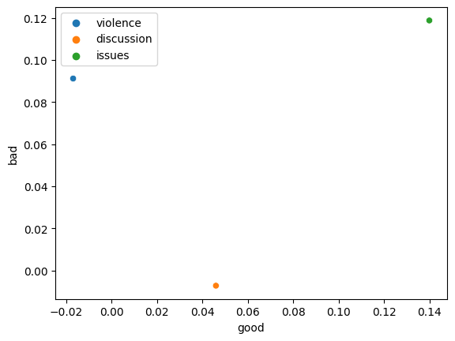

```python
sns.scatterplot(x='good', y='bad', data=pol_words_sim_2d, hue=pol_words_sim_2d.index)
```

- violence: less good, more bad
- discussion: less bad, more good
- issues: both bad and good

### Can we do this in an 1D scale?

(bad) --------------------?---- (good)

- First, let's create the vector for *bad-good* scale

```python
scale_bad_good = w2v_mod['good'] - w2v_mod['bad']
```

```python
cosine_similarity(w2v_mod['good'], w2v_mod['bad'])
```

```
0.7190051674842834
```

```python
len(scale_bad_good)
```

```
300
```

```python
violence_score = cosine_similarity(w2v_mod['violence'], scale_bad_good)
violence_score
```

```
-0.14850080013275146
```

```python
discussion_score = cosine_similarity(w2v_mod['discussion'], scale_bad_good)
discussion_score
```

```
0.06724762171506882
```

# 2. Sentiment Analysis with NLTK

"The Natural Language Toolkit (NLTK) is a suite of libraries and programs for symbolic and statistical natural language processing for English written in the Python programming language." for more information see: https://www.nltk.org/

We are going to use NLTK and Spacy to determine if text expresses positive sentiment, negative sentiment, or if it's neutral.

```python
# adapted from https://github.com/Jcharis/Natural-Language-Processing-Tutorials/blob/master/NLP%20with%20SpaCy-%20Adding%20Extensions%20Attributes%20in%20SpaCy(How%20to%20use%20sentiment%20analysis%20in%20SpaCy).ipynb
import nltk
```

"VADER (Valence Aware Dictionary and sEntiment Reasoner) is a lexicon and rule-based sentiment analysis tool that is specifically attuned to sentiments expressed in social media."

for more see: https://github.com/cjhutto/vaderSentiment

```python
nltk.download('vader_lexicon')
```

```
True
```

We are going to extend the spacy functionality with the SentimentIntensityAnalyzer function from NLTK.

```python
from nltk.sentiment.vader import SentimentIntensityAnalyzer
sent_analyzer = SentimentIntensityAnalyzer()
def sentiment_scores(docx):
    return sent_analyzer.polarity_scores(docx.text)
```

```python
sent_analyzer.polarity_scores("Great!")
```

```
{'neg': 0.0, 'neu': 0.0, 'pos': 1.0, 'compound': 0.6588}
```

```python
from spacy.tokens import Doc
Doc.set_extension("sentimenter",getter=sentiment_scores)
```

```python
nlp("This introduction was great but the conclusions were terrible")._.sentimenter
```

```
{'neg': 0.303, 'neu': 0.511, 'pos': 0.186, 'compound': -0.3818}
```

Let's apply this sentiment analysis to product reviews on Amazon

```python
r = pd.read_csv('https://raw.githubusercontent.com/umsi-data-science/data/main/small_reviews.csv',index_col=0)
# random sample of original dataset at https://www.kaggle.com/snap/amazon-fine-food-reviews
```

```python
r.head()
```

|  | Score | Summary | Text |
| --- | --- | --- | --- |
| 244509 | 4 | Love Happy Tot | I just love the happy tot baby food line. It s... |
| 87295 | 4 | Feelin Hot Hot Hot | Curry has become one of my favorite foods over... |
| 377094 | 5 | Wow. Very Maple-y | Just tried this for the first time, and I'm qu... |
| 44261 | 4 | Good dark, rich coffee for breakfast time | After trying lots of different blends in K-Cup... |
| 398439 | 5 | Fantastic coffee! | Exceptional coffee all around - rich, full, wi... |

We'll use the apply function to transform text with spacy's nlp function.

```python
r['compound_sentiment_rating'] = r['Text'].apply(lambda x: nlp(x)._.sentimenter['compound'])
```

```python
r[['Score','compound_sentiment_rating','Text']].head(10)
```

|  | Score | compound_sentiment_rating | Text |
| --- | --- | --- | --- |
| 244509 | 4 | 0.9558 | I just love the happy tot baby food line. It s... |
| 87295 | 4 | 0.9742 | Curry has become one of my favorite foods over... |
| 377094 | 5 | 0.9383 | Just tried this for the first time, and I'm qu... |
| 44261 | 4 | 0.8476 | After trying lots of different blends in K-Cup... |
| 398439 | 5 | 0.5983 | Exceptional coffee all around - rich, full, wi... |
| 269511 | 5 | 0.9652 | These are a delicious vegan alternative to reg... |
| 89042 | 1 | -0.6048 | I have never cared for sweetened cereal as I w... |
| 225284 | 3 | 0.8029 | I've been looking for dried organic mango that... |
| 92943 | 3 | -0.1971 | This meal-in-a-box was alright, but not amazin... |
| 22875 | 4 | 0.2732 | This product works well with most kinds of mea... |

```python
r.iloc[6].Text
```

```
"I have never cared for sweetened cereal as I was not raised on it. When I found Purely O's a few years ago I was happy to have found a cereal that did not contain sugar or corn products which I need to avoid because of a corn allergy.  I had intended to buy another box today. I took the time to rea…
```

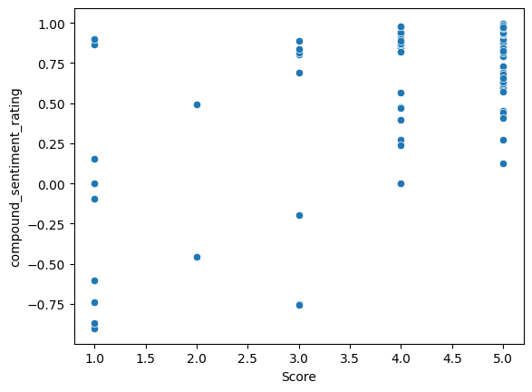

```python
sns.scatterplot(x='Score',y='compound_sentiment_rating',data=r)
```

```python
import statsmodels.api as sm
import statsmodels.formula.api as smf
```

```python
model0 = smf.ols("compound_sentiment_rating ~ Score ", data=r)
model0.fit().summary()
```

OLS Regression Results

| Dep. Variable: | compound_sentiment_rating | R-squared: | 0.430 |
| --- | --- | --- | --- |
| Model: | OLS | Adj. R-squared: | 0.424 |
| Method: | Least Squares | F-statistic: | 73.92 |
| Date: | Thu, 12 Oct 2023 | Prob (F-statistic): | 1.32e-13 |
| Time: | 20:19:42 | Log-Likelihood: | -38.820 |
| No. Observations: | 100 | AIC: | 81.64 |
| Df Residuals: | 98 | BIC: | 86.85 |
| Df Model: | 1 |  |  |
| Covariance Type: | nonrobust |  |  |

|  | coef | std err | t | P>\|t\| | [0.025 | 0.975] |
| --- | --- | --- | --- | --- | --- | --- |
| Intercept | -0.3960 | 0.128 | -3.094 | 0.003 | -0.650 | -0.142 |
| Score | 0.2508 | 0.029 | 8.598 | 0.000 | 0.193 | 0.309 |

| Omnibus: | 11.481 | Durbin-Watson: | 1.670 |
| --- | --- | --- | --- |
| Prob(Omnibus): | 0.003 | Jarque-Bera (JB): | 15.888 |
| Skew: | -0.548 | Prob(JB): | 0.000355 |
| Kurtosis: | 4.617 | Cond. No. | 16.3 |

Notes:  
[1] Standard Errors assume that the covariance matrix of the errors is correctly specified.